# COGS 108 - Final Project

### Exploring the Data

To further explore our data, we decided to find the most popular restaurants in order to see if there were any commonalities between 'successful' restaurants.

```python
# Number of reviews and average rating of each fast food business
ff_bus_name = fast_ratings_df['name'].unique()

ff_popularity = pd.DataFrame(columns=['name', 'avg_rating', 'review_count'])
for name in ff_bus_name:
    name_df = fast_ratings_df[fast_ratings_df['name'] == name]
    avg_rating = name_df.rating.mean()
    num_reviews = name_df.review_count.sum()
    ff_popularity = ff_popularity.append({'name': name, 'avg_rating': avg_rating, 'review_count': num_reviews}, ignore_index=True)

ff_popularity
```

|  | name | avg_rating | review_count |
| --- | --- | --- | --- |
| 0 | taco bell | 2.728261 | 1861 |
| 1 | mcdonald's | 2.390710 | 5646 |
| 2 | wendy's | 2.778986 | 953 |
| 3 | frisch's big boy | 3.250000 | 154 |
| 4 | lee's famous recipe chicken | 3.958333 | 74 |
| ... | ... | ... | ... |
| 180 | charkies | 4.500000 | 163 |
| 181 | hot dog on a stick | 4.000000 | 193 |
| 182 | sbarro | 3.000000 | 9 |
| 183 | backyard burgers | 3.500000 | 78 |
| 184 | taco del mar | 4.500000 | 40 |

185 rows × 3 columns

In order to determine the least/most popular restaurant we need to take into account two factors: the number of reviews and the rating of the restaurant. We can multiply the two numbers and find which gets the highest score. This gets a score that takes into consideration both the number of reviews and ratings. It works by estimating that each review would give the average rating (point) and scores it based on the total points it gets from all the reviews.

```python
fast_names = fast_ratings_df.drop(columns=['latitude', 'longitude'])
fast_names = fast_names.pivot_table(index = 'name', columns='rating', aggfunc = 'sum')
fast_names
```

| rating name | review_count 0.0 | review_count 1.0 | review_count 1.5 | review_count 2.0 | review_count 2.5 | review_count 3.0 | review_count 3.5 | review_count 4.0 | review_count 4.5 | review_count 5.0 |
| --- | --- | --- | --- | --- | --- | --- | --- | --- | --- | --- |
| 7-eleven | NaN | NaN | NaN | 6.0 | NaN | 1.0 | NaN | 7.0 | NaN | NaN |
| a&w | NaN | NaN | NaN | 25.0 | NaN | 5.0 | NaN | NaN | NaN | NaN |
| a&w restaurant | NaN | 1.0 | NaN | NaN | 44.0 | 17.0 | 72.0 | 112.0 | 32.0 | NaN |
| amigos/kings classic | NaN | NaN | NaN | NaN | NaN | NaN | NaN | NaN | 5.0 | NaN |
| arby's | NaN | 6.0 | 37.0 | 44.0 | 196.0 | 119.0 | 103.0 | 98.0 | 51.0 | 18.0 |
| ... | ... | ... | ... | ... | ... | ... | ... | ... | ... | ... |
| white castle | NaN | NaN | NaN | NaN | NaN | 49.0 | 15.0 | 99.0 | NaN | NaN |
| wienerschnitzel | NaN | NaN | NaN | NaN | 3.0 | NaN | NaN | NaN | NaN | NaN |
| wingstop | NaN | 1.0 | NaN | NaN | NaN | 25.0 | 80.0 | 20.0 | 27.0 | NaN |
| world wrapps | NaN | NaN | NaN | NaN | NaN | NaN | NaN | NaN | 274.0 | NaN |
| wu's fine chinese cuisine | NaN | NaN | NaN | NaN | NaN | NaN | 121.0 | NaN | NaN | NaN |

185 rows × 10 columns

```python
# Uses review count and average rating to calculate popularity score
ff_popularity['score'] = ff_popularity.apply(lambda row: row.avg_rating * row.review_count, axis=1)
ff_popularity.sort_values(by='score', ascending=False)
```

|  | name | avg_rating | review_count | score |
| --- | --- | --- | --- | --- |
| 72 | the halal guys | 3.875000 | 20056 | 77717.000000 |
| 43 | in-n-out burger | 4.016949 | 13967 | 56104.728814 |
| 34 | chick-fil-a | 4.033186 | 12818 | 51697.376106 |
| 32 | starbucks | 3.481203 | 4559 | 15870.804511 |
| 1 | mcdonald's | 2.390710 | 5646 | 13497.950820 |
| ... | ... | ... | ... | ... |
| 177 | blimpie | 4.500000 | 2 | 9.000000 |
| 139 | wienerschnitzel | 2.500000 | 3 | 7.500000 |
| 68 | taco bueno | 1.500000 | 3 | 4.500000 |
| 116 | einstein bros bagels | 4.000000 | 1 | 4.000000 |
| 133 | great steak | 3.000000 | 1 | 3.000000 |

185 rows × 4 columns

This chart displays the fast food chain restaurants at the top with the highest popularity scores and the ones with the lowest scores at the bottom. The Halal Guys ranks at the top with the Great Steak at the bottom.

```python
# Find the most and least popular
ff_most_fav = ff_popularity.loc[ff_popularity['score'].idxmax()]
ff_least_fav = ff_popularity.loc[ff_popularity['score'].idxmin()]

print('Most popular: ', ff_most_fav)
print('\n')
print('Least popular: ', ff_least_fav)
```

```
Most popular:  name            the halal guys
avg_rating               3.875
review_count             20056
score                    77717
Name: 72, dtype: object


Least popular:  name            great steak
avg_rating                3
review_count              1
score                     3
Name: 133, dtype: object
```

```python
non_fast_names = yelp_df.drop(columns=['latitude', 'longitude'])
non_fast_names = non_fast_names.pivot_table(index = 'name', columns='rating', aggfunc = 'sum')
non_fast_names
```

| rating name | review_count 3.0 | review_count 3.5 | review_count 4.0 | review_count 4.5 | review_count 5.0 |
| --- | --- | --- | --- | --- | --- |
| 11-worth cafe | NaN | NaN | NaN | 370.0 | NaN |
| 1608 crafthouse | NaN | NaN | NaN | 449.0 | NaN |
| 2 doors down | NaN | NaN | 234.0 | NaN | NaN |
| 49th state brewing co - anchorage | NaN | NaN | 986.0 | NaN | NaN |
| a baked joint | NaN | NaN | NaN | 1829.0 | NaN |
| ... | ... | ... | ... | ... | ... |
| zahav | NaN | NaN | NaN | 2891.0 | NaN |
| zaytinya | NaN | NaN | 4606.0 | NaN | NaN |
| zest kitchen & bar | NaN | NaN | NaN | 784.0 | NaN |
| zombie burger + drink lab | NaN | NaN | 1257.0 | NaN | NaN |
| zookz sandwiches | NaN | NaN | NaN | 880.0 | NaN |

999 rows × 5 columns

```python
# Number of reviews and average rating of each non fast food business
nff_bus_name = yelp_df['name'].unique()

nff_popularity = pd.DataFrame(columns=['name', 'avg_rating', 'review_count'])
for name in nff_bus_name:
    name_df = yelp_df[yelp_df['name'] == name]
    avg_rating = name_df.rating.mean()
    num_reviews = name_df.review_count.sum()
    nff_popularity = nff_popularity.append({'name': name, 'avg_rating': avg_rating, 'review_count': num_reviews}, ignore_index=True)

nff_popularity
```

|  | name | avg_rating | review_count |
| --- | --- | --- | --- |
| 0 | el barrio | 4.5 | 618 |
| 1 | saw's soul kitchen | 4.5 | 783 |
| 2 | yo' mama's | 4.5 | 355 |
| 3 | carrigan's public house | 4.5 | 527 |
| 4 | highlands bar & grill | 4.5 | 304 |
| ... | ... | ... | ... |
| 994 | albany restaurant bar & liquormart | 3.5 | 115 |
| 995 | wasabi japanese grill & bar | 3.5 | 118 |
| 996 | l'osteria mondello | 4.0 | 79 |
| 997 | destination taiwan | 5.0 | 16 |
| 998 | mort's bagels | 4.5 | 46 |

999 rows × 3 columns

```python
# Uses review count and average rating to calculate popularity score
nff_popularity['score'] = nff_popularity.apply(lambda row: row.avg_rating * row.review_count, axis=1)
nff_popularity.sort_values(by='score', ascending=False)
```

|  | name | avg_rating | review_count | score |
| --- | --- | --- | --- | --- |
| 358 | bottega louie | 4.0 | 16921 | 67684.0 |
| 140 | founding farmers - washington | 4.0 | 13586 | 54344.0 |
| 636 | katz's delicatessen | 4.0 | 12161 | 48644.0 |
| 219 | marukame udon | 4.5 | 9559 | 43015.5 |
| 564 | bacchanal buffet | 4.0 | 10656 | 42624.0 |
| ... | ... | ... | ... | ... |
| 169 | the thai kitchen | 5.0 | 4 | 20.0 |
| 168 | rick's place bar and grill | 4.5 | 4 | 18.0 |
| 176 | dalton's back 9 bar & grill | 4.5 | 4 | 18.0 |
| 173 | colborn's kitchen | 5.0 | 3 | 15.0 |
| 179 | smokey's d's catering & bbq | 4.5 | 3 | 13.5 |

999 rows × 4 columns

This chart displays the non fast food restaurants at the top with the highest popularity scores and the ones with the lowest scores at the bottom. Bottega Louie ranks at the top with Smokey's D's Catering & BBQ at the bottom.

```python
# Find the most and least popular
nff_most_fav = nff_popularity.loc[nff_popularity['score'].idxmax()]
nff_least_fav = nff_popularity.loc[nff_popularity['score'].idxmin()]

print('Most popular: ', nff_most_fav)
print('\n')
print('Least popular: ', nff_least_fav)
```

```
Most popular:  name            bottega louie
avg_rating                  4
review_count            16921
score                   67684
Name: 358, dtype: object


Least popular:  name            smokey's d's catering & bbq
avg_rating                              4.5
review_count                              3
score                                  13.5
Name: 179, dtype: object
```

We explored the popularity to see if there was a significant difference between the popularity of the most and least popular restaurants between fast foods and non fast foods. If there was a significant difference, we wanted to explore possible reasonings for this. However, we did not find any.

### Testing Distributions

We observed a >1 star difference in rating between non fast food vs fast food restaurants, where non fast food restaurants were rated more highly. It's possible that there are some confounding variables at play. For our purposes, we want to look into cuisine as a confounder. We want to test if this difference in rating could be attributed to differences in cuisine distrubution among non fast food vs fast food restaurants.

To begin, we will test if there are significant differences in rating across cuisines in non fast food and fast food restaurants.

**Non Fast Food**

We will test the question "Does the type of cuisine have a significant correlation to the non fast food restaurant rating?"

```python
# check the restaurant count in each category
count=[]
for x in cuisine:
    count.append(len(all_cuisine_ratings[x]["rating"]))
print(cuisine,"\n",count)
```

```
['american', 'mexican', 'thai', 'greek', 'indian', 'japanese', 'spanish', 'chinese', 'french', 'italian', 'mediterranean']
 [261, 46, 22, 10, 0, 28, 10, 3, 16, 52, 29]
```

```python
# remove greek, indian, spanish, chinese, and french from our cuisine list because they have too few restaurants
# (we need n>=20 for kurtosistest).
print("cuisine: ", cuisine)
count=[]
cuis20 = [x for x in cuisine if not len(all_cuisine_ratings[x]["rating"])<20]
print("cuis20: ", cuis20)
```

```
cuisine:  ['american', 'mexican', 'thai', 'greek', 'indian', 'japanese', 'spanish', 'chinese', 'french', 'italian', 'mediterranean']
cuis20:  ['american', 'mexican', 'thai', 'japanese', 'italian', 'mediterranean']
```

```python
# test normality of each cuisine's ratings
norm=[]
for x in cuis20:
    st,p=stats.normaltest(all_cuisine_ratings[x]["rating"])
    norm.append(p)
norm
```

```
[0.0005374038287795762,
 4.5119415235748956e-05,
 0.7710620493184326,
 2.521288699591849e-05,
 0.3808909148317702,
 0.22779359800864385]
```

```python
# test variance of each cuisine's ratings
var=[]
for x in cuis20:
    var.append(all_cuisine_ratings[x]["rating"].var())
var
```

```
[0.08156498673740034,
 0.11352657004830922,
 0.07846320346320342,
 0.06712962962962964,
 0.08710407239819001,
 0.05972906403940883]
```

Before discussing the results of the ANOVA (aka generalized t-test for multiple groups), let's consider if all of the necessary conditions are met.

1. Equal variance among groups: Yes. Our variances range from 0.0597 - 0.113. The ratio between the most extreme variances is roughly 1.89. As a rule of thumb, since 1.89 < 2, this is a sufficient reason in order to use an ANOVA.
2. Large enough sample size: Yes. We considered only cuisines with more than 20 samples.
3. Normally distributed: This is debatable. The first thing that we need to consider is the nature of our data. Within a particular cuisine, we have a set of restaurants which each have a rating that is a multiple of 0.5. This multiple of 0.5 is obtained by aggregating individual reviews of that restaurant which range from 1 to 5 stars. These reviews are averaged and then rounded to the nearest multiple of 0.5. When using normaltest with an alpha value of 0.05, American, Mexican, and Japanese cuisines did not pass. This result might be a result of rounding error: It's possible that when considering pre-rounded ratings, we had a normal distribution with a very low standard deviation, but rounding clumped up most of our data into a few bins. We will further explore the normality of these 3 cases below.
4. Data are continuous: Yes. See #3. While each restaurant rating is not continuous, the pre-rounded mean is. This adds some rounding error in our data, but we should still be able to perform the ANOVA.

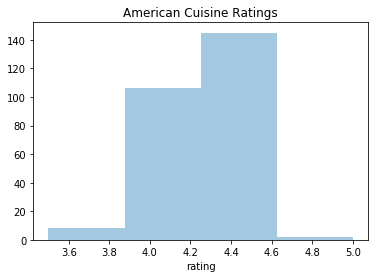

```python
# Let's further explore the normality of American, Mexican, and Japanses Cuisines
sns.distplot(all_cuisine_ratings["american"]["rating"], kde=False, bins=4).set_title('American Cuisine Ratings')

f1 = plt.gcf()
```

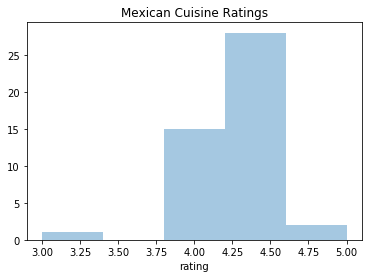

```python
sns.distplot(all_cuisine_ratings["mexican"]["rating"], kde=False, bins=5).set_title('Mexican Cuisine Ratings')

f1 = plt.gcf()
```

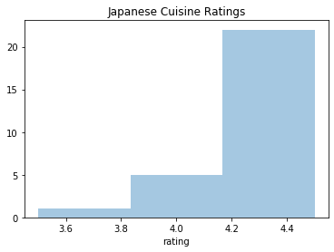

```python
sns.distplot(all_cuisine_ratings["japanese"]["rating"], kde=False,bins=3).set_title('Japanese Cuisine Ratings')

f1 = plt.gcf()
```

These distplots give credence to the hypothesis that pre-rounded ratings follow a normal distribution: most of the ratings are clumped into 1 or 2 categories! With this, we will use the ANOVA to test our original hypothesis.

```python
# Let's check if the variations in rating across cuisines is due to random chance via an ANOVA:
stats.f_oneway(all_cuisine_ratings["american"]["rating"],
             all_cuisine_ratings["mexican"]["rating"],
             all_cuisine_ratings["thai"]["rating"],
              all_cuisine_ratings["japanese"]["rating"],
              all_cuisine_ratings["italian"]["rating"],
              all_cuisine_ratings["mediterranean"]["rating"])
```

```
F_onewayResult(statistic=3.4691401226376284, pvalue=0.004377614743612544)
```

With a p value below our alpha of .05, we can conclude that it is very unlikely that cuisines do not affect rating of a non fast food restaurant. Our anova suggest that differences in ratings across cuisines are not a result of random chance. We conclude that the type of cuisine of a non fast food restaurant influences the rating of a restaurant.

**Fast Food**

```python
# check the restaurant count in each category
count=[]
for x in cuisine:
    count.append(len(all_fast_ratings[x]))
print(cuisine,"\n",count)
```

```
['american', 'mexican', 'thai', 'greek', 'indian', 'japanese', 'spanish', 'chinese', 'french', 'italian', 'mediterranean']
 [230, 140, 1, 2, 0, 1, 1, 40, 0, 370, 13]
```

```python
# remove greek, indian, spanish, chinese, and french from our cuisine list because they have too few restaurants
# (we need n>=20 for kurtosistest).
print("cuisine: ", cuisine)
count=[]
cuis20 = [x for x in cuisine if not len(all_fast_ratings[x]["rating"])<20]
print("cuis20: ", cuis20)
```

```
cuisine:  ['american', 'mexican', 'thai', 'greek', 'indian', 'japanese', 'spanish', 'chinese', 'french', 'italian', 'mediterranean']
cuis20:  ['american', 'mexican', 'chinese', 'italian']
```

```python
# test normality of each cuisine's ratings
norm=[]
for x in cuis20:
    st,p=stats.normaltest(all_fast_ratings[x]["rating"])
    norm.append(p)
norm
```

```
[0.12194149547972807,
 0.01108811288803714,
 0.06326858815156687,
 0.07220017935050475]
```

```python
# test variance of each cuisine's ratings
var=[]
for x in cuis20:
    var.append(all_fast_ratings[x]["rating"].var())
var
```

```
[0.5183263717486236, 0.6297404933196297, 0.6472756410256406, 0.89302900461437]
```

Before discussing the results of the ANOVA test, let's consider if all of the necessary conditions are met.

1. Equal variance among groups: Yes. They range from 0.518 to 0.893. The ratio between the most extreme variances is roughly 1.7. As a rule of thumb, since 1.7<2, this is good enough to use an ANOVA.
2. Large enough sample size: Yes, we considered only cuisines with more than 20 samples.
3. Normally distributed: All but Mexican cuisine pass the normality test. We follow the same methodology as the non-fast food data: it is possible that when considering pre-rounded ratings, we had a normal distribution with a very low standard deviation, but rounding clumped up most of our data into a few bins. We will further explore the normality of Mexican cuisine below.
4. Data are continuous: Yes. See #3. While each restaurant rating is not continuous, the pre-rounded mean is. This adds some rounding error in our data, but we should still be able to perform the ANOVA.

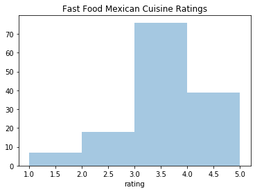

```python
# Let's further explore the normality of American, Mexican, and Japanses Cuisines
sns.distplot(all_fast_ratings["mexican"]["rating"], kde=False, bins=4).set_title('Fast Food Mexican Cuisine Ratings')

f1 = plt.gcf()
```

The distplot give credence to the hypothesis that pre-rounded ratings follow a normal distribution: most of the ratings are clumped into 1 or 2 categories! With this, we will use the ANOVA to test our original hypothesis.

```python
# Let's check if the variations in rating across cuisines is due to random chance via an ANOVA:
stats.f_oneway(all_fast_ratings["american"]["rating"],
             all_fast_ratings["mexican"]["rating"],
             all_fast_ratings["chinese"]["rating"],
              all_fast_ratings["italian"]["rating"])
```

```
F_onewayResult(statistic=35.71791774324262, pvalue=1.2517558299252336e-21)
```

With a p-value below our alpha of 0.05, we can conclude that it is very unlikely that the type of cuisine does not affect rating. Our ANOVA suggests that differences in ratings across cuisines in fast food are not a result of random chance. We conclude that the type of cuisine does influence the rating of a fast food restaurant.

# Ethics & Privacy

# Conclusion & Discussion

When we started on our project, we initially planned to look at the success of a restaurant and if there was correlation with location. However this proved to be challenging because the original dataset we planned to use was not representative of the entire country.

Ideally, we would have liked to find the average cuisine ratings per each state. However, the limitations of the data we could retrieve from the Yelp API prevented us from being able to accurately represent the ratings of the entire population across each state. In order to do so, we would have liked to obtain all restaurant reviews within the Yelp database. Therefore, we are very limited in the data we can find based on the resources available to the public.

Because of the limitations in data, we have adjusted our question so that we can take a more generalized approach. Our new question, “How do the ratings of a fast food restaurant compare to non fast food restaurants?”, is more generalized as we are not looking at it based on specific locations. We originally attempted to do so but found that our data was not extensive enough to account for all states. We decided to focus on fast food vs. non fast food because we thought that non fast food restaurants would be more popular than fast foods. This idea stemmed from the comparison between chain restaurants we originally had when answering the question related to location. We noticed that popular chain restaurants tend to be fast food restaurants. As such, we wanted to compare the difference between popular fast food chains and non fast food chains to see if there was a reasoning for this. We studied ratings based on cuisine across fast food and non fast food restaurants.

Based on our analysis, we found that the average rating of fast food restaurants is lower than that of non fast food restaurants, which aligns with our hypothesis. We noticed that there is a significant difference between the average ratings (>1 star difference), which we thought could be attributed to the types of cuisines available in fast food vs. non fast food restaurants. As such, we analyzed the correlation between the average ratings and the type of cuisines available for both fast food and non fast food restaurants. Our data suggests that the type of cuisine is likely to influence the rating of both non fast food restaurants and fast food restaurants.

The limitations of our data unfortunately only shows whether or not there is significant correlation between the popularity of a restaurant and the type of restaurant it is (fast food vs. non fast food, different types of cuisines). There is not sufficient data to assume a causation between the two because we do not know if there are factors unaccounted for.

# Team Contributions

The overview, research question, background, and hypothesis were created together as a collective during our group meetings. The data was gathered by Manda using the Yelp API. As for the data cleaning, analysis, and exploration, it is difficult to pinpoint who did what. Matthew did a large part of the data cleaning, and Viet structured the t-tests. Besides this, we did not assign sections but instead had everyone work on areas that they felt comfortable with or still needed to be completed. It can be said that everyone contributed equally for these parts, considering how each person has contributed to at least a portion of each section. The ethics & privacy and conclusion & discussion sections were written by Andrea, Manda, and Shih Wen. The overall project was reviewed by each team member.